# Assignment 4

Federico Manenti 790032

# Introduzione

Il task assegnato consiste nell’implementare un o più algoritmi per trovare una soluzione sub-ottimale al *Flow shop scheduling problem* . In questo caso è stato scelto il **Genetic Algorithm** e il **Tabu Search** . In seguito il risultato ottenuto sarà confrontato con il migliore conosiuto (presente sul sito [Taillard](http://mistic.heig-vd.ch/taillard/problemes.dir/ordonnancement.dir/ordonnancement.html) ) e con quello ottenuto con un algoritmo già presente in $R$ (il **Genetic Algorithm** della libreria $GA$).

## Il problema

Nel *Flow shop scheduling problem* abbiamo $n$ macchine e $m$ lavori da compiere. Ogni lavoro deve essere processato su tutte le macchine con lo steso ordine. In oltre due macchine non possono compiere lo stesso lavoro simultaneamente e il tempo per ogni lavoro cambia da macchina a macchina. L’obiettivo è quello di minimizzare il $makespan$ che corrisponde al tempo totale di esecuzione.

## Makespan

Si implementa la funzione che data la matrice di lavori e macchine (rappresentante il tempo imiegato da ogni macchina per effettuare i lavori) calcola il $makespan$.

```r
set.seed(4062019)
jobs_time <- function(mat, seq){
  mat <- mat[, seq]
  m <- matrix(0, nrow = nrow(mat), ncol = ncol(mat))

  for (row in 1:nrow(mat)) {
    for (col in 1:ncol(mat)) {
      # prima cella
      if(row == 1 & col == 1){
        m[row, col] <- mat[row, col]
      }

      # prima riga
      else if(row == 1){
        m[row, col] <- mat[row, col] + m[row, col - 1]
      }

      else{
        if(col == 1){
          m[row, col] <- m[row-1, col] + mat[row, col]
        }
        else{
          if(m[row, col-1] <= m[row-1, col]){
            m[row, col] <- mat[row, col] +  m[row-1, col]
          }
          else{
            m[row, col] <- mat[row, col] +  m[row, col-1]
          }
        }
      }
    }
  }
  return(1/as.integer(m[nrow(m), ncol(m)]))
}
```

# L’algoritmo genetico

L’algoritmo genetico è basato concettualmente sui principi che regolano l’evoluzione naturale delle specie. L’idea di base quinidi è quella avviare ricorsivamente l’algoritmo e di selezionare le soluzioni migliori ad ogni iterazione e di ricombinarle in qualche modo ($crossover$ e $mutazione$) in maniera che evolvano verso un punto di ottimo. La funzione da massimizzare si chiama $fit$ $funtion$ (nel caso corrente è $\frac {1}{makespan}$ ) e l’insieme degli elementi su cui si valuta ad ogni iterazione è chiamato $popolazione$.

## Implementazione

Ora si crea:

```r
generateRandomWork <- function(){
  vet <- c(1:nWorks)                                         # crea una permutazione casuale
  randperm(vet)
}

generateRandomPopulation <- function(popSize){               # crea una popolazione  casuale
  t(replicate(popSize, generateRandomWork()))
}

evaluateWork <- function(fitFun, works){                     # valuta il fit factor di un individuo
  fitFun(matrice, works)
}

evaluatePopulation <- function(pop){
  data.frame(index = c(1:nrow(pop)),
             fit = apply(pop, 1,
                         curry(evaluateWork, jobs_time)))    # valuta il fit factor della popolazione
}

populationStats <- function(gen, scores){
  bestScore <- max(scores$fit)
  avgScore <- mean(scores$fit)
  medianScore <- median(scores$fit)
  item = list(gen = gen, best = bestScore, avg = avgScore, median =medianScore )
  class(item)<- "traceItem"
  return(item)
}
```

```r
rouletteSelection <- function(scores, pop){
  idx = sample_n(scores, size = 2, replace = F, weight = scores$fit)$index
  pop[idx, ]
}
```

Si implementano ora anche i metodi per la $mutazione$:

```r
swapMutation <- function(p){
  pos = sample(nWorks, 2)
  p[c(pos[1], pos[2])] = p[c(pos[2], pos[1])]
  p
}
```

E il $crossover$:

```r
generateOffspring <- function(p1, p2){
  swath = round(nWorks/2)
  cut1 = sample(nWorks - swath, 1)
  cut2 = cut1 + swath-1
  off1 = rep(0, nWorks)
  sel = p1[cut1:cut2]
  off1[cut1:cut2]= sel
  r = p2[!p2 %in% sel]
  r1= r[c(1:cut1-1)]
  r2= r[c(cut1:length(r))]
  off1[c(1:cut1-1)] = r1
  off1[c((cut2+1):length(off1))] = r2
  off1
}
```

```r
trace2Dataframe <- function(trace){            # funzione per tener traccia dei risultati
bestVect=NULL
genVect = NULL
avgVect=NULL
medianVect =NULL
for (i in seq(1,length(trace), by = 4)) {
gen <- trace[i]$gen
genVect = append(genVect, gen)
best <- trace[i+1]$best
bestVect = append(bestVect, best)
avg <- trace[i+2]$avg
avgVect <- append(avgVect, avg)
med <- trace[i+3]$median
medianVect <- append(medianVect, med)
}
df <- data.frame(Gen= genVect, Best=bestVect, Avg=avgVect, Median=medianVect)
return(df)
}
```

L’algoritmo vero e proprio è:

```r
simpleGA <- function(popSize = 200, crossProb = 0.8, mutProbability = 0.2, numGenerations = 1000) {
  pop <- generateRandomPopulation(popSize)
  trace = NULL
  for (gen in c(1:numGenerations)) {
    newPop = NULL
    scores <- evaluatePopulation(pop)

    newPop <- rbind(newPop, pop[head(scores[order(scores$fit,decreasing = T), ],2)$index,])
    if(!(gen %% 50) ) {
      trace <- append(trace, populationStats(gen,scores))
    }
    for (i in c(2:(popSize/2))) {
      # selection
      parents <- rouletteSelection(scores, pop)
      # crossover
      if (runif(1)<=crossProb) {
        off1 <- generateOffspring(parents[1,], parents[2,])
        off2 <- generateOffspring(parents[2,], parents[1,])
      }
      else{
        off1 <- parents[1,]; off2<- parents[2,]
      }
      newPop <- rbind(newPop, as.array(off1), as.array(off2))
    }
    # mutatazione
    for (i in c(1:popSize)) {
      if(runif(1) <= mutProbability){
        newPop[i,] <- swapMutation(newPop[i,])
      }
    }
    pop = newPop
  }

  pop <- as.data.frame(pop)
  pop <- pop %>%
    unite(sec, c(colnames(pop)), sep = ", ", remove = FALSE)
  pop$res <- scores$fit
  pop <- pop[, c(1, ncol(pop))]
  max <- max(pop$res)
  pop <- pop[pop$res == max, ]    # solo i valori più alti di fit function


  m <- as.numeric(1/pop$res[1])
  pop$makespan <- m
  rownames(pop) <- 1:nrow(pop)
  return(list(trace2Dataframe(trace), pop))
}
```

## Test

Per verificarne la correttezza si testa ora l’algoritmo creato su un piccolo insieme di dati di cui si conosce la soluzione ottima.

```r
matrice <- read.table("/home/federico/Scrivania/Università/decision_model/Assignment/Assignment_4/Soluzione/test.txt", quote="\"", comment.char="")
matrice <- as.matrix(matrice)
nWorks <- ncol(matrice)
```

```r
result <- simpleGA(popSize = 50)
```

| sec | res | makespan |
| --- | --- | --- |
| 3, 5, 4, 1, 2 | 0.0022173 | 451 |
| 3, 5, 4, 2, 1 | 0.0022173 | 451 |
| 4, 5, 1, 3, 2 | 0.0022173 | 451 |
| 5, 2, 3, 1, 4 | 0.0022173 | 451 |
| 5, 3, 1, 4, 2 | 0.0022173 | 451 |
| 5, 4, 1, 3, 2 | 0.0022173 | 451 |
| 3, 2, 5, 1, 4 | 0.0022173 | 451 |
| 3, 4, 2, 1, 5 | 0.0022173 | 451 |
| 3, 4, 1, 5, 2 | 0.0022173 | 451 |
| 3, 5, 1, 4, 2 | 0.0022173 | 451 |

Il $makespan$ trovato quindi rispecchia quello aspettato e l’algoritmo funziona.

# Tabu Search

Il $Tabu$ $Search$ è una procedura metaeuristica che migliora l’efficienza di un classico algoritmo di ricerca locale memorizzando informazioni riguardo il processo di ricerca. Ad ogni iterazione si considera l’intorno della soluzione trovata e si eliminano alcune mosse in base alla memoria dell’algoritmo. Ciò permette di sfugire alla trappola dei minimi/massimi locali. Ciò però non comporta l’assoluta certezza di trovare la soluzione ottima.

```r
swap_Tabu <- function(v, i , j){

    aux <- v[i]
    v[i] <- v[j]
    v[j] <- aux
    return(v)
}
```

```r
TS <- function(mat, iter, tabu.size=7, report.evol=FALSE){

  sol <- generateRandomWork()
    n <- length(sol)
  obj <- 1/jobs_time(mat, sol)
  evol <- numeric(iter)

  solbest <- sol
  objbest <- obj

  k <- 1

  tabu.list <- matrix(numeric(tabu.size*2), tabu.size, 2)


  while(k<=iter){

    #bisogna trovare la soluzione migliore per l'iterazione
    move <- numeric(2)
    objiter <- Inf
    soliter <- numeric(n)
    update.tabu <- FALSE

    for(i in 1:(n-1)){
      for(j in (i+1):n){
        soltest <- swap_Tabu(sol, i, j)
        objtest <- 1/jobs_time(mat, soltest)

        is.tabu <- FALSE
        for(s in 1:tabu.size) if(tabu.list[s,1]==i & tabu.list[s,2]==j) is.tabu <- TRUE

        if(is.tabu){
          #mla mossa è tabu

          if(objtest < objbest){
            soliter <- soltest
            objiter <- objtest
            update.tabu <- FALSE
          }
        }
        else{
          #la mossa non è tabu
          if(objtest < objiter){
            soliter <- soltest
            objiter <- objtest
            update.tabu <- TRUE
            move <- c(i,j)
          }
        }
      }
    }

    sol <- soliter
    obj <- objiter

    #update della soluzione migliore
    if(obj < objbest){
      objbest <- obj
      solbest <- sol
    }

    if(update.tabu){
      for(s in tabu.size:2) tabu.list[s, ] <- tabu.list[s-1, ]
      tabu.list[1, ] <- move
    }

    evol[k] <- obj
    k <- k+1

  }

  if(report.evol)
    return(list(sol=solbest, obj=objbest, evol=evol))
  else
    return(list(sol=solbest, obj=objbest))
}
```

## Test

Anche qui controlliamo la corretteza dell’algoritmo

```r
TA_result <- TS(matrice, 100)
```

```r
TA_result
```

```
## $sol
## [1] 3 5 4 1 2
##
## $obj
## [1] 451
```

Anche qui il valore del $makespan$ è corretto.

# Calcoli

Vengono utilizzati come dati quelli presenti sul sito di $Taillard$ perchè affiancati da una soluzione ottima e dal makespan migliore trovato, utile per il confronto dei risultati dei diversi algoritmi.

## 20 lavori per 5 macchine

Come primo set viene utilizzato uno dei più piccoli composto da 20 lavori e 5 macchine.

```r
matrice <- read.table("/home/federico/Scrivania/Università/decision_model/Assignment/Assignment_4/Soluzione/20_lavori5_macchine.txt", quote="\"", comment.char="")
matrice <- as.matrix(matrice)
nWorks <- ncol(matrice)
```

In questo caso il makespan ottimo riportato sul sito è di $1278$.

Applichiamo l’algoritmo genetico implementato precedentemente.

```r
result <- simpleGA(popSize = 300, numGenerations = 1000)
```

| sec | res | makespan |
| --- | --- | --- |
| 18, 1, 7, 9, 3, 10, 4, 6, 14, 11, 12, 13, 17, 15, 19, 5, 2, 8, 20, 16 | 0.0007491 | 1335 |

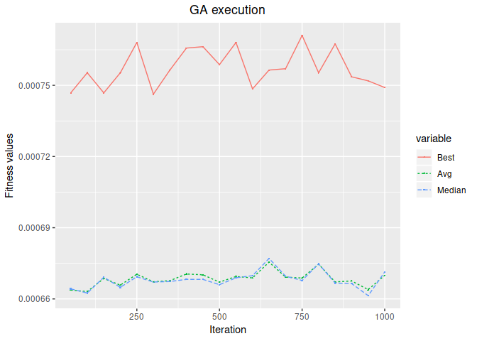

```r
df = melt(result[[1]], id.var = "Gen")
  ggplot(df, aes(x = Gen, y = value, group = variable, colour = variable)) +
  xlab("Iteration") + ylab("Fitness values") +
  geom_point(aes(shape = variable), size=0.5) +
  geom_line(aes(lty = variable)) +
  ggtitle("GA execution") +
  theme(plot.title = element_text(hjust = 0.5))
```

Come si nota dal grafico precedente il valore della $fit$ $function$ dell’algoritmo genetico hand-made non è in continua crescita per le generazioni, ma sembra oscillare intorno a un punto.

Applichiamo anche il $Tabu$ $Search$:

```r
TA_result <- TS(matrice, 1000)
```

```r
TA_result
```

```
## $sol
##  [1]  3 17 15 13 11  7  4  2  6  1  9 14 19 18 16  8  5 12 10 20
##
## $obj
## [1] 1297
```

Infine utilizziamo l’algoritmo presente in $GA$:

```r
GA.fit <- ga(type = "permutation",
          fitness = jobs_time,
          mat = matrice,
          lower = 1,
          upper = 20, #numero lavori
          popSize = 300,
          maxiter = 1000,
          run = 500,
          pmutation = 0.2,
          keepBest = TRUE,
          monitor = FALSE)
summary(GA.fit)
```

```
## ── Genetic Algorithm ───────────────────
##
## GA settings:
## Type                  =  permutation
## Population size       =  300
## Number of generations =  1000
## Elitism               =  15
## Crossover probability =  0.8
## Mutation probability  =  0.2
##
## GA results:
## Iterations             = 702
## Fitness function value = 0.00077101
## Solutions =
##       x1 x2 x3 x4 x5 x6 x7 x8 x9 x10  ...  x19 x20
## [1,]  14 17  1  9 11 15 13 19  8   7        10  20
## [2,]  14 15 17  1  9  8 19 13 11   7        10  20
## [3,]   1  9  8 19 13 11  7  6  2  14        10  20
## [4,]  14 17  1 15 19  8 11  9 13   7        10  20
## [5,]  14 17  1 19  8  9 13 15 11   7        10  20
## [6,]  14  1 17  9  8 19 13 15 11   7        10  20
## [7,]  14 17  1  9 11 15 13 19  8   7        10  20
## [8,]  14 17  1  9 11 15 13 19  8   7        10  20
## [9,]  14 17  1 15  8 11  9 13 19   7        10  20
## [10,] 14  1 17  9  8 19 13 15 11   7        10  20
##  ...
## [14,] 14 17  1  9 11 15 13 19  8   6        10  20
## [15,]  1 15 14 17  9  8 11 13 19   7        10  20
```

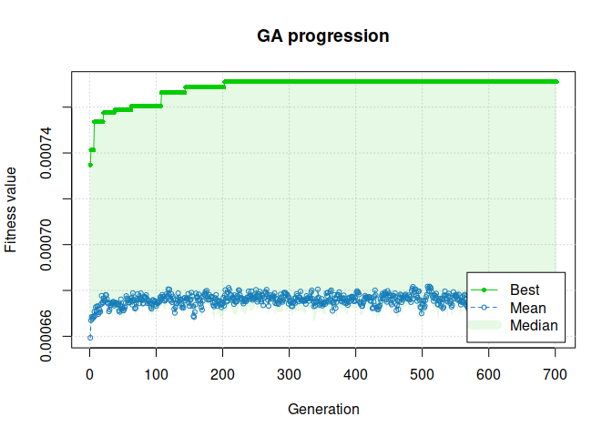

```r
out <- plot(GA.fit, main = "GA progression")
```

Il $fitness$ $value$ dell’algoritmo presente nel pacchetto $GA$ invece raggiunge un palteau e rimane stabile.

```r
risultati <- data.frame(t(c(result[[2]]$makespan[1],TA_result$obj ,1/summary(GA.fit)$fitness, 1278)))
colnames(risultati) <- c("GA hand-made", "Tabu Search", "GA", "Taillard")
```

| GA hand-made | Tabu Search | GA | Taillard |
| --- | --- | --- | --- |
| 1335 | 1297 | 1297 | 1278 |

## 100 lavori per 20 macchine

Viene utilizzato ora un set più grande. La scelta della seguente matrice 100 x 20 è data dal tesmpo di esecuzione del codicea causa dei più algoritmi utilizzati.

```r
matrice <- read.table("/home/federico/Scrivania/Università/decision_model/Assignment/Assignment_4/Soluzione/100_lavori20_macchine.txt", quote="\"", comment.char="")
matrice <- as.matrix(matrice)
nWorks <- ncol(matrice)
```

Il $makespan$ ottimale riportato varia tra $5851$ e $6286$.

Ancora una volta applichiamo i tre algoritmi.

$GA$ hand-made:

```r
result <- simpleGA(popSize = 200, numGenerations = 1000)
```

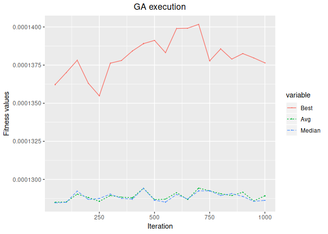

| sec | res | makespan |
| --- | --- | --- |
| 66, 16, 33, 14, 31, 90, 79, 85, 78, 100, 56, 40, 32, 50, 61, 53, 65, 71, 7, 76, 27, 69, 49, 6, 22, 1, 73, 54, 25, 47, 48, 84, 21, 99, 10, 34, 93, 3, 38, 81, 4, 46, 9, 88, 59, 68, 75, 77, 2, 20, 12, 92… | 0.0001376 | 7265 |
| 66, 16, 33, 14, 31, 90, 79, 85, 78, 100, 56, 40, 32, 50, 61, 53, 65, 71, 7, 76, 27, 69, 49, 6, 22, 1, 73, 54, 25, 47, 48, 84, 21, 99, 10, 34, 93, 3, 38, 81, 4, 46, 9, 88, 59, 68, 75, 77, 2, 20, 12, 92… | 0.0001376 | 7265 |

```r
df = melt(result[[1]], id.var = "Gen")
  ggplot(df, aes(x = Gen, y = value, group = variable, colour = variable)) +
  xlab("Iteration") + ylab("Fitness values") +
  geom_point(aes(shape = variable), size=0.5) +
  geom_line(aes(lty = variable)) +
  ggtitle("GA execution") +
  theme(plot.title = element_text(hjust = 0.5))
```

$Tabu$ $Search$: Il numero di iterazioni è fissato a 100 a causa del tempo di esecuzione:

```r
TA_result <- TS(matrice, 100)
```

$GA$ di $R$:

```r
GA.fit <- ga(type = "permutation",
          fitness = jobs_time,
          mat = matrice,
          lower = 1,
          upper = 100, #numero lavori
          popSize = 200,
          maxiter = 1000,
          run = 1000,
          pmutation = 0.2,
          keepBest = TRUE,
          monitor = FALSE)
summary(GA.fit)
```

```
## ── Genetic Algorithm ───────────────────
##
## GA settings:
## Type                  =  permutation
## Population size       =  200
## Number of generations =  1000
## Elitism               =  10
## Crossover probability =  0.8
## Mutation probability  =  0.2
##
## GA results:
## Iterations             = 1000
## Fitness function value = 0.0001442377
## Solution =
##      x1 x2 x3 x4 x5 x6 x7 x8 x9 x10  ...  x99 x100
## [1,] 22 55 24 28 86  5 48 61 54  62         8   78
```

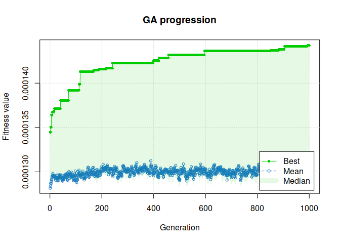

```r
out <- plot(GA.fit, main = "GA progression")
```

Dal grafico della $fitness$ possiamo iptizzare che il valore ottimale potrebbe crescere ancora con altre iterazioni, ma già con questi parametri iniziali la risoluzione richiede molto tempo e quinidi per questo task non verranno modificati.

Infine confrontiamo i quattro diversi $makespan$

```r
risultati <- data.frame(t(c(result[[2]]$makespan[1],TA_result$obj ,1/summary(GA.fit)$fitness, "6286 - 5851")))
colnames(risultati) <- c("GA hand-made", "Tabu Search", "GA", "Taillard")
```

| GA hand-made | Tabu Search | GA | Taillard |
| --- | --- | --- | --- |
| 7265 | 6473 | 6933 | 6286 - 5851 |

In questo caso si possono trarre conclusioni simili, ossia che l’algoritmo hand-made non ottiene il risultato ottimale, ma comunque ci si avvicina. Il $Tabu$ $Search$ e il $GA$ contenuto in $R$ invece si accostano di più alla soluzione ottimale. Si potrebbe provare a migliorare il risultato cambiando qualche parametro iniziale, ma già con una *popolation size* di $200$ e $1000$ iterazioni il $GA$ è molto lento e con una matrice così grande lo è anche il $Tabu$ $Search$ .